# MACHINE LEARNING - ENSEMBLE TECHNIQUES

## Ricardo López Ruiz

Date: 7/04/2021

## Abstract:

Different machine learning models are used to predict the potential customers who are going to purchase some newly introduced tourism packages.

## Models used in this project:

'Decision Tree', 'Bagging Classifier', 'Bagging with Logistic Regression', 'Bagging tuned', 'Random Forest', 'Tuned Random Forest', 'AdaBoost Classifier', 'Gradient Boosting', 'XGBoost Classifier', 'Tuned XGBoost', 'Stacking Model'

# Project - Travel Package Purchase Prediction

## **Context:**

You as a Data Scientist at "Visit with us" travel company have to analyze the customers' data and information to provide recommendations to the Policy Maker and Marketing Team and also build a model to predict the potential customer who is going to purchase the newly introduced package.

## **Problem Statement:**

You are a Data Scientist for a tourism company named "Visit with us". The Policy Maker of the company wants to enable and establish a viable business model to expand the customer base. A viable business model is a central concept that helps you to understand the existing ways of doing the business and how to change the ways for the benefit of the tourism sector. One of the ways to expand the customer base is to introduce a new offering of packages. Currently, there are 5 types of packages the company is offering - Basic, Standard, Deluxe, Super Deluxe, King. Looking at the data of the last year, we observed that 18% of the customers purchased the packages.

However, the marketing cost was quite high because customers were contacted at random without looking at the available information. The company is now planning to launch a new product i.e. Wellness Tourism Package. Wellness Tourism is defined as Travel that allows the traveler to maintain, enhance or kick-start a healthy lifestyle, and support or increase one's sense of well-being. However, this time company wants to harness the available data of existing and potential customers to make the marketing expenditure more efficient.

## **Objective:**

- To predict which customer is more likely to purchase the newly introduced travel package.

## **Data Description:**

### Data Dictionary

Customer details:

```
CustomerID: Unique customer ID
ProdTaken: Product taken flag
Age: Age of customer
PreferredLoginDevice: Preferred login device of the customer in last month
CityTier: City tier
Occupation: Occupation of customer
Gender: Gender of customer
NumberOfPersonVisited: Total number of person came with customer
PreferredPropertyStar: Preferred hotel property rating by customer
MaritalStatus: Marital status of customer
NumberOfTrips: Average number of the trip in a year by customer
Passport: Customer passport flag
OwnCar: Customers owns a car flag
NumberOfChildrenVisited: Total number of children visit with customer
Designation: Designation of the customer in the current organization
MonthlyIncome: Gross monthly income of the customer
```

Customer interaction data:

```
PitchSatisfactionScore: Sales pitch satisfactory score
ProductPitched: Product pitched by a salesperson
NumberOfFollowups: Total number of follow up has been done by sales person after sales pitch
DurationOfPitch: Duration of the pitch by a salesman to customer
```

## Index

- Overview of the dataset
- EDA
- Data Pre-processing
- Model Building - Bagging
- Bagging Model Performance
- Model Building - Boosting
- Boosting Model Performance
- Insights and Business Recommendations

## Overview of the dataset

**Let's start by importing libraries we need.**

```python
import warnings
warnings.filterwarnings("ignore")

import numpy as np
import pandas as pd
import seaborn as sns
import matplotlib.pyplot as plt
%matplotlib inline
```

```python
#Loading dataset
data=pd.read_excel("Tourism.xlsx", sheet_name="Tourism")
```

**View the first rows of the dataset.**

```python
data.head(10)
```

|  | CustomerID | ProdTaken | Age | PreferredLoginDevice | CityTier | DurationOfPitch | Occupation | Gender | NumberOfPersonVisited | NumberOfFollowups | ProductPitched | PreferredPropertyStar | MaritalStatus | NumberOfTrips | Passport | PitchSatisfactionScore | OwnCar | NumberOfChildrenVisited | Designation | MonthlyIncome |
| --- | --- | --- | --- | --- | --- | --- | --- | --- | --- | --- | --- | --- | --- | --- | --- | --- | --- | --- | --- | --- |
| 0 | 200000 | 1 | 41.0 | Self Enquiry | 3 | 6.0 | Salaried | Female | 3 | 3.0 | Super Deluxe | 3.0 | Single | 1.0 | 1 | 2 | 1 | 0.0 | Manager | 20993.0 |
| 1 | 200001 | 0 | 49.0 | Company Invited | 1 | 14.0 | Salaried | Male | 3 | 4.0 | Super Deluxe | 4.0 | Divorced | 2.0 | 0 | 3 | 1 | 2.0 | Manager | 20130.0 |
| 2 | 200002 | 1 | 37.0 | Self Enquiry | 1 | 8.0 | Free Lancer | Male | 3 | 4.0 | Multi | 3.0 | Single | 7.0 | 1 | 3 | 0 | 0.0 | Executive | 17090.0 |
| 3 | 200003 | 0 | 33.0 | Company Invited | 1 | 9.0 | Salaried | Female | 2 | 3.0 | Multi | 3.0 | Divorced | 2.0 | 1 | 5 | 1 | 1.0 | Executive | 17909.0 |
| 4 | 200004 | 0 | NaN | Self Enquiry | 1 | 8.0 | Small Business | Male | 2 | 3.0 | Multi | 4.0 | Divorced | 1.0 | 0 | 5 | 1 | 0.0 | Executive | 18468.0 |
| 5 | 200005 | 0 | 32.0 | Company Invited | 1 | 8.0 | Salaried | Male | 3 | 3.0 | Multi | 3.0 | Single | 1.0 | 0 | 5 | 1 | 1.0 | Executive | 18068.0 |
| 6 | 200006 | 0 | 59.0 | Self Enquiry | 1 | 9.0 | Small Business | Female | 2 | 2.0 | Multi | 5.0 | Divorced | 5.0 | 1 | 2 | 1 | 1.0 | Executive | 17670.0 |
| 7 | 200007 | 0 | 30.0 | Self Enquiry | 1 | 30.0 | Salaried | Male | 3 | 3.0 | Multi | 3.0 | Married | 2.0 | 0 | 2 | 0 | 1.0 | Executive | 17693.0 |
| 8 | 200008 | 0 | 38.0 | Company Invited | 1 | 29.0 | Salaried | Male | 2 | 4.0 | Standard | 3.0 | Unmarried | 1.0 | 0 | 3 | 0 | 0.0 | Senior Manager | 24526.0 |
| 9 | 200009 | 0 | 36.0 | Self Enquiry | 1 | 33.0 | Small Business | Male | 3 | 3.0 | Super Deluxe | 3.0 | Divorced | 7.0 | 0 | 3 | 1 | 0.0 | Manager | 20237.0 |

**Check data types and number of non-null values for each column.**

```python
data.info()
```

```
<class 'pandas.core.frame.DataFrame'>
RangeIndex: 4888 entries, 0 to 4887
Data columns (total 20 columns):
 #   Column                   Non-Null Count  Dtype
---  ------                   --------------  -----
 0   CustomerID               4888 non-null   int64
 1   ProdTaken                4888 non-null   int64
 2   Age                      4662 non-null   float64
 3   PreferredLoginDevice     4863 non-null   object
 4   CityTier                 4888 non-null   int64
 5   DurationOfPitch          4637 non-null   float64
 6   Occupation               4888 non-null   object
 7   Gender                   4888 non-null   object
 8   NumberOfPersonVisited    4888 non-null   int64
 9   NumberOfFollowups        4843 non-null   float64
 10  ProductPitched           4888 non-null   object
 11  PreferredPropertyStar    4862 non-null   float64
 12  MaritalStatus            4888 non-null   object
 13  NumberOfTrips            4748 non-null   float64
 14  Passport                 4888 non-null   int64
 15  PitchSatisfactionScore   4888 non-null   int64
 16  OwnCar                   4888 non-null   int64
 17  NumberOfChildrenVisited  4822 non-null   float64
 18  Designation              4888 non-null   object
 19  MonthlyIncome            4655 non-null   float64
dtypes: float64(7), int64(7), object(6)
memory usage: 763.9+ KB
```

- We can see that there are total 20 columns and 4888 number of rows in the dataset.
- All columns' data type is either integer or float or object.
- There are several columns where number of non-null value of each column is not equal to number of total rows in the dataset i.e. there are null values to decide about them. We can further confirm this using 'isna()' method.

```python
#Total of null data by rows
data.isna().sum()
```

```
CustomerID                   0
ProdTaken                    0
Age                        226
PreferredLoginDevice        25
CityTier                     0
DurationOfPitch            251
Occupation                   0
Gender                       0
NumberOfPersonVisited        0
NumberOfFollowups           45
ProductPitched               0
PreferredPropertyStar       26
MaritalStatus                0
NumberOfTrips              140
Passport                     0
PitchSatisfactionScore       0
OwnCar                       0
NumberOfChildrenVisited     66
Designation                  0
MonthlyIncome              233
dtype: int64
```

```python
#Total of number of rows with some null data
data.isnull().any(axis=1).sum()
```

```
760
```

**Checking the percentage of customers with ProdTaken=1**

```python
#Percentage of customers taking the products
print(len(data))
print(data["ProdTaken"].value_counts())
print('% Costumers Taking Product = ',100*data["ProdTaken"].value_counts()[1]/len(data),'%')
```

```
4888
0    3968
1     920
Name: ProdTaken, dtype: int64
% Costumers Taking Product =  18.821603927986907 %
```

## First steps to treat the data

- We can drop 'CustomerID' column as it is an ID variable and will not add value to the model.
- There are missing values in the data to be treated: we drop all these columns because finally they represent no more than the 15% of the data.
- Lets convert the columns with an 'object' datatype into categorical variables.
- Lets convert the columns with an 'float64' datatype into 'int64' datatype, because clearly they are integers.
- We check that the dropping of the rows with missing values does not modify the percentage of customers taking the products.

```python
#Dropping one column from the dataframe "data" in a new dataframe "data1"
data1 = data.drop(columns=['CustomerID']).copy()
data1.shape
```

```
(4888, 19)
```

```python
# Removing the rows with some null data
data1.dropna(inplace=True)
data1.shape
```

```
(4128, 19)
```

```python
# Reconverting the 'object' data in 'categorical' data
for feature in data1.columns: # Loop through all columns in the dataframe
    if data1[feature].dtype == 'object': # Only apply for columns with categorical strings
        data1[feature] = pd.Categorical(data1[feature])# Replace strings with an integer
data1.info()
```

```
<class 'pandas.core.frame.DataFrame'>
Int64Index: 4128 entries, 0 to 4887
Data columns (total 19 columns):
 #   Column                   Non-Null Count  Dtype
---  ------                   --------------  -----
 0   ProdTaken                4128 non-null   int64
 1   Age                      4128 non-null   float64
 2   PreferredLoginDevice     4128 non-null   category
 3   CityTier                 4128 non-null   int64
 4   DurationOfPitch          4128 non-null   float64
 5   Occupation               4128 non-null   category
 6   Gender                   4128 non-null   category
 7   NumberOfPersonVisited    4128 non-null   int64
 8   NumberOfFollowups        4128 non-null   float64
 9   ProductPitched           4128 non-null   category
 10  PreferredPropertyStar    4128 non-null   float64
 11  MaritalStatus            4128 non-null   category
 12  NumberOfTrips            4128 non-null   float64
 13  Passport                 4128 non-null   int64
 14  PitchSatisfactionScore   4128 non-null   int64
 15  OwnCar                   4128 non-null   int64
 16  NumberOfChildrenVisited  4128 non-null   float64
 17  Designation              4128 non-null   category
 18  MonthlyIncome            4128 non-null   float64
dtypes: category(6), float64(7), int64(6)
memory usage: 476.6 KB
```

```python
# Reconverting the 'float64' data 'int64' data
for feature in data1.columns: # Loop through all columns in the dataframe
    if data1[feature].dtype == 'float64': # Only apply for columns with float64 type
        data1[feature] = data1[feature].astype('int64')# Replace floats with an integers
data1.info()
```

```
<class 'pandas.core.frame.DataFrame'>
Int64Index: 4128 entries, 0 to 4887
Data columns (total 19 columns):
 #   Column                   Non-Null Count  Dtype
---  ------                   --------------  -----
 0   ProdTaken                4128 non-null   int64
 1   Age                      4128 non-null   int64
 2   PreferredLoginDevice     4128 non-null   category
 3   CityTier                 4128 non-null   int64
 4   DurationOfPitch          4128 non-null   int64
 5   Occupation               4128 non-null   category
 6   Gender                   4128 non-null   category
 7   NumberOfPersonVisited    4128 non-null   int64
 8   NumberOfFollowups        4128 non-null   int64
 9   ProductPitched           4128 non-null   category
 10  PreferredPropertyStar    4128 non-null   int64
 11  MaritalStatus            4128 non-null   category
 12  NumberOfTrips            4128 non-null   int64
 13  Passport                 4128 non-null   int64
 14  PitchSatisfactionScore   4128 non-null   int64
 15  OwnCar                   4128 non-null   int64
 16  NumberOfChildrenVisited  4128 non-null   int64
 17  Designation              4128 non-null   category
 18  MonthlyIncome            4128 non-null   int64
dtypes: category(6), int64(13)
memory usage: 476.6 KB
```

```python
# Checking that the percentage of rows with ProdTaken=1 after the drop of missing values is conserved
print(len(data))
print(data["ProdTaken"].value_counts())
print('% Costumers Taking Product = ',100*data["ProdTaken"].value_counts()[1]/len(data),'%')
print(len(data1))
print(data1["ProdTaken"].value_counts())
print('% Costumers Taking Product = ',100*data1["ProdTaken"].value_counts()[1]/len(data1),'%')
```

```
4888
0    3968
1     920
Name: ProdTaken, dtype: int64
% Costumers Taking Product =  18.821603927986907 %
4128
0    3331
1     797
Name: ProdTaken, dtype: int64
% Costumers Taking Product =  19.30717054263566 %
```

```python
# Checking the chages in the data are ok
data1.head(5)
```

|  | ProdTaken | Age | PreferredLoginDevice | CityTier | DurationOfPitch | Occupation | Gender | NumberOfPersonVisited | NumberOfFollowups | ProductPitched | PreferredPropertyStar | MaritalStatus | NumberOfTrips | Passport | PitchSatisfactionScore | OwnCar | NumberOfChildrenVisited | Designation | MonthlyIncome |
| --- | --- | --- | --- | --- | --- | --- | --- | --- | --- | --- | --- | --- | --- | --- | --- | --- | --- | --- | --- |
| 0 | 1 | 41 | Self Enquiry | 3 | 6 | Salaried | Female | 3 | 3 | Super Deluxe | 3 | Single | 1 | 1 | 2 | 1 | 0 | Manager | 20993 |
| 1 | 0 | 49 | Company Invited | 1 | 14 | Salaried | Male | 3 | 4 | Super Deluxe | 4 | Divorced | 2 | 0 | 3 | 1 | 2 | Manager | 20130 |
| 2 | 1 | 37 | Self Enquiry | 1 | 8 | Free Lancer | Male | 3 | 4 | Multi | 3 | Single | 7 | 1 | 3 | 0 | 0 | Executive | 17090 |
| 3 | 0 | 33 | Company Invited | 1 | 9 | Salaried | Female | 2 | 3 | Multi | 3 | Divorced | 2 | 1 | 5 | 1 | 1 | Executive | 17909 |
| 5 | 0 | 32 | Company Invited | 1 | 8 | Salaried | Male | 3 | 3 | Multi | 3 | Single | 1 | 0 | 5 | 1 | 1 | Executive | 18068 |

## EDA

### Perform an Exploratory Data Analysis on the data

- Univariate analysis - Bivariate analysis - Use appropriate visualizations to identify the patterns and insights - Come up with a customer profile (characteristics of a customer) of the different packages - Any other exploratory deep dive

### Illustrate the insights based on EDA

- Key meaningful observations on the relationship between variables

**Summary of the dataset**

```python
# Summary of columns with near-continuous data
data1[['Age','DurationOfPitch','NumberOfTrips','MonthlyIncome']].describe().T
```

|  | count | mean | std | min | 25% | 50% | 75% | max |
| --- | --- | --- | --- | --- | --- | --- | --- | --- |
| Age | 4128.0 | 37.231831 | 9.174521 | 18.0 | 31.0 | 36.0 | 43.0 | 61.0 |
| DurationOfPitch | 4128.0 | 15.584787 | 8.398142 | 5.0 | 9.0 | 14.0 | 20.0 | 127.0 |
| NumberOfTrips | 4128.0 | 3.295300 | 1.856300 | 1.0 | 2.0 | 3.0 | 4.0 | 22.0 |
| MonthlyIncome | 4128.0 | 23178.464147 | 4506.614622 | 1000.0 | 20751.0 | 22418.0 | 25301.0 | 98678.0 |

- Mean and median value of 'Age' is approx 37 and 36, respectively
- Mean and median value for 'DurationOfPitch' is approx 15 and 14, respectively
- Mean and median value for 'NumberOftrips' is approx 3
- Mean and median value for 'MontlyIncome' is approx 23178 and 22418, respectively
- These variables seem to have not much skewed distributions, as mean and median are very similar for all them
- Also the excessive max value in 'DurationOfPitch', 'NumberOftrips' and 'MontlyIncome' warn us about the existence of outliers

**Number of unique values in each column**

```python
data1.nunique()
```

```
ProdTaken                     2
Age                          44
PreferredLoginDevice          2
CityTier                      3
DurationOfPitch              33
Occupation                    4
Gender                        3
NumberOfPersonVisited         5
NumberOfFollowups             6
ProductPitched                5
PreferredPropertyStar         3
MaritalStatus                 4
NumberOfTrips                12
Passport                      2
PitchSatisfactionScore        5
OwnCar                        2
NumberOfChildrenVisited       4
Designation                   5
MonthlyIncome              2182
dtype: int64
```

**Correction/Grouping of data values**

```python
#we check number of grades in the different columns
print(data1['CityTier'].value_counts())
print(data1['Occupation'].value_counts())
print(data1['Gender'].value_counts())
print(data1['ProductPitched'].value_counts())
print(data1['PreferredPropertyStar'].value_counts())
print(data1['MaritalStatus'].value_counts())
print(data1['PitchSatisfactionScore'].value_counts())
print(data1['OwnCar'].value_counts())
print(data1['NumberOfChildrenVisited'].value_counts())
print(data1['Designation'].value_counts())
```

```
1    2678
3    1288
2     162
Name: CityTier, dtype: int64
Salaried          1999
Small Business    1746
Large Business     381
Free Lancer          2
Name: Occupation, dtype: int64
Male       2463
Female     1510
Fe Male     155
Name: Gender, dtype: int64
Multi           1615
Super Deluxe    1422
Standard         737
Deluxe           250
King             104
Name: ProductPitched, dtype: int64
3    2541
5     801
4     786
Name: PreferredPropertyStar, dtype: int64
Married      1990
Divorced      789
Unmarried     682
Single        667
Name: MaritalStatus, dtype: int64
3    1257
1     806
5     798
4     767
2     500
Name: PitchSatisfactionScore, dtype: int64
1    2527
0    1601
Name: OwnCar, dtype: int64
1    1800
2    1186
0     849
3     293
Name: NumberOfChildrenVisited, dtype: int64
Executive         1615
Manager           1422
Senior Manager     737
AVP                250
VP                 104
Name: Designation, dtype: int64
```

- Occupation: We can change 'Free Lancer' by 'Large Business' (given that there are only 2 customers of this type)
- Gender: We can change 'Fe Male' by 'Female'
- MaritalStatus: We can change 'Unmarried' by 'Single'
- Designation: We can change 'VP' by 'AVP' (supposing it is the same designation)

```python
# Changing the errors in the values signaled in the previous cell
data1.Occupation.replace({'Free Lancer':'Large Business'},inplace=True)
data1.Gender.replace({'Fe Male':'Female'},inplace=True)
data1.MaritalStatus.replace({'Unmarried':'Single'},inplace=True)
data1.Designation.replace({'VP':'AVP'},inplace=True)
```

```python
#Checking that the change is done correctly
print(data1['Occupation'].value_counts())
print(data1['Gender'].value_counts())
print(data1['MaritalStatus'].value_counts())
print(data1['Designation'].value_counts())
data1.info()
```

```
Salaried          1999
Small Business    1746
Large Business     383
Name: Occupation, dtype: int64
Male      2463
Female    1665
Name: Gender, dtype: int64
Married     1990
Single      1349
Divorced     789
Name: MaritalStatus, dtype: int64
Executive         1615
Manager           1422
Senior Manager     737
AVP                354
Name: Designation, dtype: int64
<class 'pandas.core.frame.DataFrame'>
Int64Index: 4128 entries, 0 to 4887
Data columns (total 19 columns):
 #   Column                   Non-Null Count  Dtype
---  ------                   --------------  -----
 0   ProdTaken                4128 non-null   int64
 1   Age                      4128 non-null   int64
 2   PreferredLoginDevice     4128 non-null   category
 3   CityTier                 4128 non-null   int64
 4   DurationOfPitch          4128 non-null   int64
 5   Occupation               4128 non-null   object
 6   Gender                   4128 non-null   object
 7   NumberOfPersonVisited    4128 non-null   int64
 8   NumberOfFollowups        4128 non-null   int64
 9   ProductPitched           4128 non-null   category
 10  PreferredPropertyStar    4128 non-null   int64
 11  MaritalStatus            4128 non-null   object
 12  NumberOfTrips            4128 non-null   int64
 13  Passport                 4128 non-null   int64
 14  PitchSatisfactionScore   4128 non-null   int64
 15  OwnCar                   4128 non-null   int64
 16  NumberOfChildrenVisited  4128 non-null   int64
 17  Designation              4128 non-null   object
 18  MonthlyIncome            4128 non-null   int64
dtypes: category(2), int64(13), object(4)
memory usage: 588.9+ KB
```

```python
# Reconverting again the 'object' data in 'categorical' data
for feature in data1.columns: # Loop through all columns in the dataframe
    if data1[feature].dtype == 'object': # Only apply for columns with categorical strings
        data1[feature] = pd.Categorical(data1[feature])# Replace strings with an integer
data1.info()
```

```
<class 'pandas.core.frame.DataFrame'>
Int64Index: 4128 entries, 0 to 4887
Data columns (total 19 columns):
 #   Column                   Non-Null Count  Dtype
---  ------                   --------------  -----
 0   ProdTaken                4128 non-null   int64
 1   Age                      4128 non-null   int64
 2   PreferredLoginDevice     4128 non-null   category
 3   CityTier                 4128 non-null   int64
 4   DurationOfPitch          4128 non-null   int64
 5   Occupation               4128 non-null   category
 6   Gender                   4128 non-null   category
 7   NumberOfPersonVisited    4128 non-null   int64
 8   NumberOfFollowups        4128 non-null   int64
 9   ProductPitched           4128 non-null   category
 10  PreferredPropertyStar    4128 non-null   int64
 11  MaritalStatus            4128 non-null   category
 12  NumberOfTrips            4128 non-null   int64
 13  Passport                 4128 non-null   int64
 14  PitchSatisfactionScore   4128 non-null   int64
 15  OwnCar                   4128 non-null   int64
 16  NumberOfChildrenVisited  4128 non-null   int64
 17  Designation              4128 non-null   category
 18  MonthlyIncome            4128 non-null   int64
dtypes: category(6), int64(13)
memory usage: 476.5 KB
```

```python
# Checking the unique values per column
data1.nunique()
```

```
ProdTaken                     2
Age                          44
PreferredLoginDevice          2
CityTier                      3
DurationOfPitch              33
Occupation                    3
Gender                        2
NumberOfPersonVisited         5
NumberOfFollowups             6
ProductPitched                5
PreferredPropertyStar         3
MaritalStatus                 3
NumberOfTrips                12
Passport                      2
PitchSatisfactionScore        5
OwnCar                        2
NumberOfChildrenVisited       4
Designation                   4
MonthlyIncome              2182
dtype: int64
```

### Univariate analysis

```python
# While doing uni-variate analysis of numerical variables we want to study their central tendency
# and dispersion.
# Let us write a function that will help us create boxplot and histogram for any input numerical
# variable.
# This function takes the numerical column as the input and returns the boxplots
# and histograms for the variable.

def histogram_boxplot(feature, figsize=(15,10), bins = None):
    """ Boxplot and histogram combined
    feature: 1-d feature array
    figsize: size of fig (default (9,8))
    bins: number of bins (default None / auto)
    """
    f2, (ax_box2, ax_hist2) = plt.subplots(nrows = 2, # Number of rows of the subplot grid= 2
                                           sharex = True, # x-axis will be shared among all subplots
                                           gridspec_kw = {"height_ratios": (.25, .75)},
                                           figsize = figsize
                                           ) # creating the 2 subplots
    sns.boxplot(feature, ax=ax_box2, showmeans=True, color='violet') # boxplot will be created and a star will indicate the mean value of the column
    sns.distplot(feature, kde=F, ax=ax_hist2, bins=bins,palette="winter") if bins else sns.distplot(feature, kde=False, ax=ax_hist2) # For histogram
    mean=feature.mean()
    median=feature.median()
    ax_hist2.axvline(median, color='black', linestyle='-') # Add median to the histogram
    ax_hist2.axvline(mean, color='green', linestyle='--') # Add mean to the histogram
```

**Observations on Age**

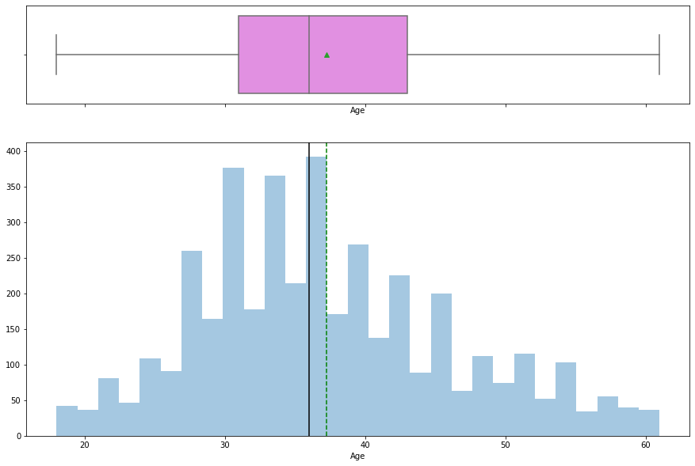

```python
histogram_boxplot(data1['Age'])
```

- Age has an approx symmetric distribution with mean and median near to 36
- As evident from the boxplot, there are no outliers in the distribution for this variable

**Observations on 'DurationOfPitch'**

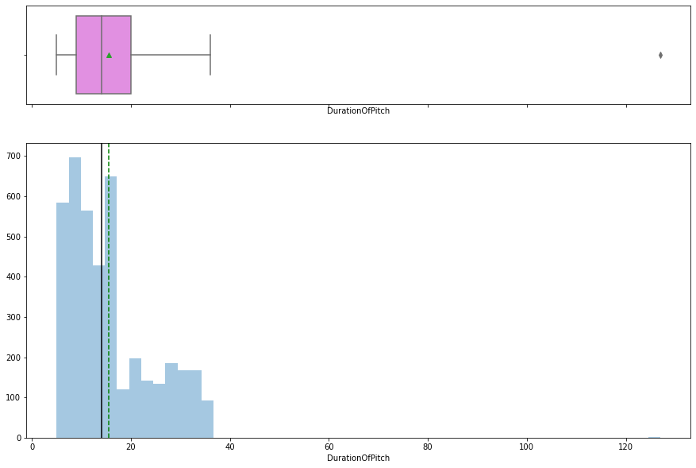

```python
histogram_boxplot(data1['DurationOfPitch'])
```

- The distribution is not symmetrically distributed but the mean and median are approx. equal to 15
- There are at least 2 outliers in the distribution of this variables

**Observations on 'NumberOfTrips'**

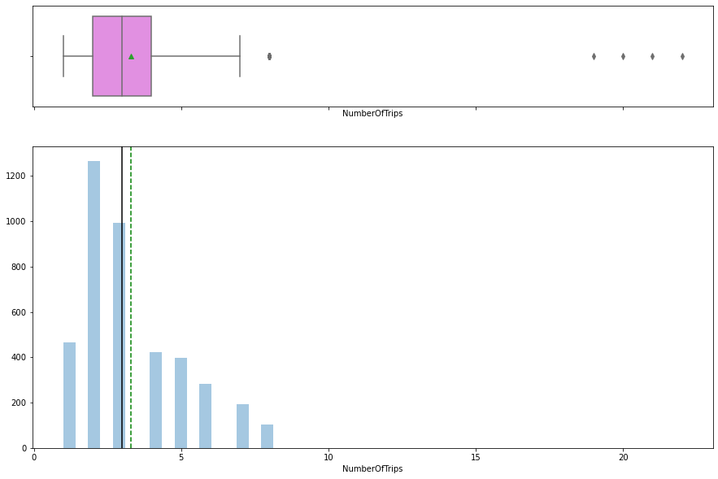

```python
histogram_boxplot(data1['NumberOfTrips'])
```

- The distribution is not symmetrically distributed but the mean and median are approx. equal to 3
- There are at least 5 outliers in the distribution of this variables

**Observations on 'MonthlyIncome'**

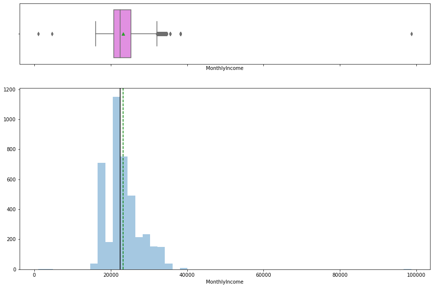

```python
histogram_boxplot(data1['MonthlyIncome'])
```

- MonthlyIncome has a right skewed distribution and the value near 22500 has the highest count among all observations
- Distribution is not symmetric but mean and median are approx equal with value equal to 22500
- There are many outliers in this variable

```python
#Top 5 highest/smallest values in MonthlyIncome
print(data1['MonthlyIncome'].nlargest())
print(data1['MonthlyIncome'].nsmallest())
```

```
2482    98678
3258    38304
4728    38304
3573    38291
3560    38264
Name: MonthlyIncome, dtype: int64
142      1000
2586     4678
513     16009
1983    16009
727     16051
Name: MonthlyIncome, dtype: int64
```

**Function to create barplots that indicate percentage for each category**

```python
def perc_on_bar(feature):
    '''
    plot
    feature: categorical feature
    the function won't work if a column is passed in hue parameter
    '''
    #Creating a countplot for the feature
    sns.set(rc={'figure.figsize':(15,7)})
    ax=sns.countplot(x=feature, data=data)

    total = len(feature) # length of the column
    for p in ax.patches:
        percentage = '{:.1f}%'.format(100 * p.get_height()/total) # percentage of each class of the category
        x = p.get_x() + p.get_width() / 2 - 0.25 # width of the plot
        y = p.get_y() + p.get_height()           # height of the plot
        ax.annotate(percentage, (x, y), size = 14) # annotate the percantage

    plt.show() # show the plot
```

**Barplots for each category**

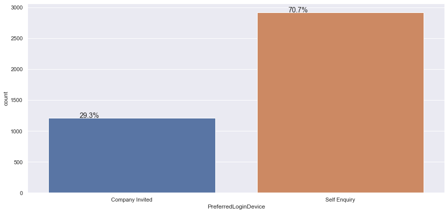

```python
perc_on_bar(data1['PreferredLoginDevice'])
```

- Around the 70% of the costumers have Self Enquiry as LoginDevice

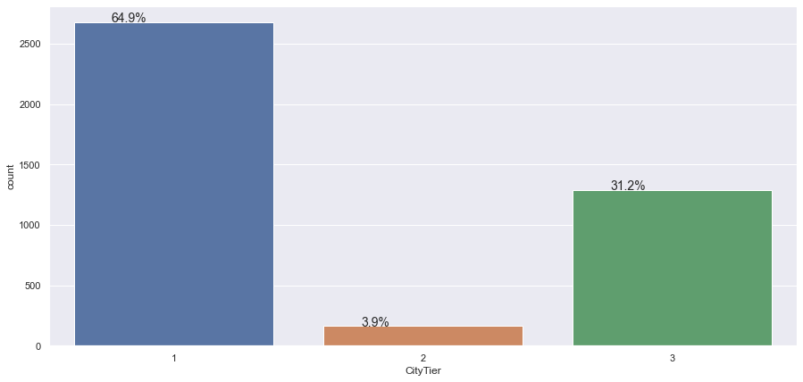

```python
perc_on_bar(data1['CityTier'])
```

- Most of the costumers live in Tier1 (Big cities) and Tier3 (Small cities) cities

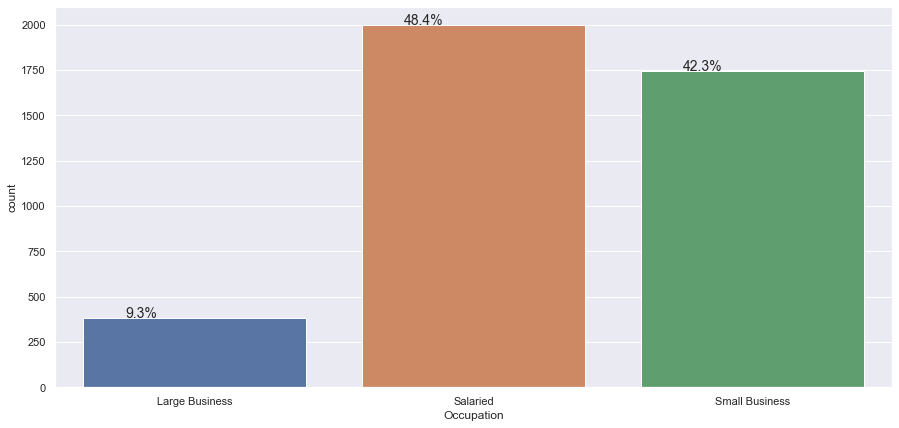

```python
perc_on_bar(data1['Occupation'])
```

- Most of the costumers are Salaried and Small Business owners

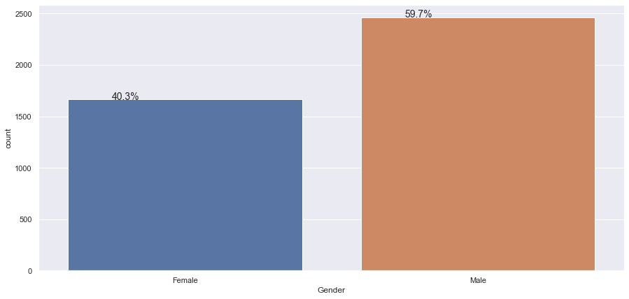

```python
perc_on_bar(data1['Gender'])
```

- Majority of costumers are Male (60%) vs. Female (40%)

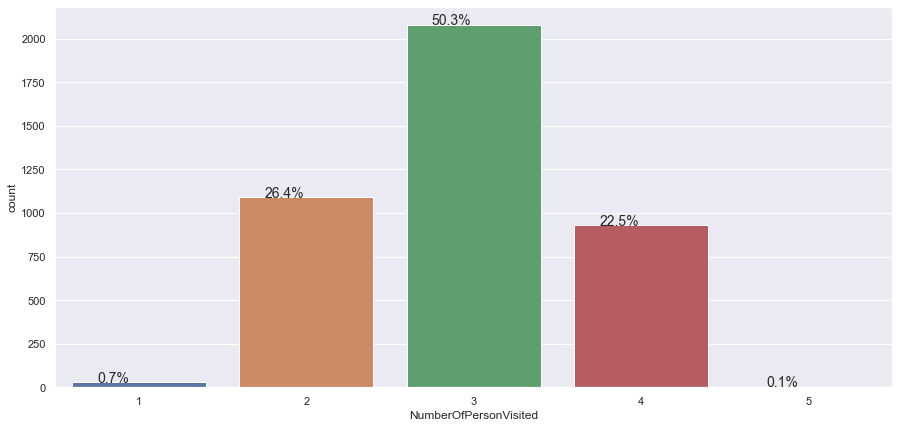

```python
perc_on_bar(data1['NumberOfPersonVisited'])
```

- A number of 3 people/family members has the majority of costumers visited

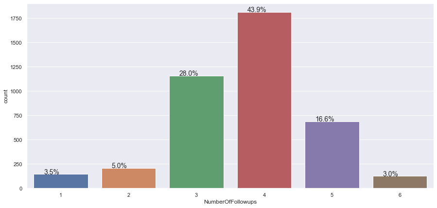

```python
perc_on_bar(data1['NumberOfFollowups'])
```

- A number of 3 and 4 follows up are the more usual numbers got by the sales person after sales pitch

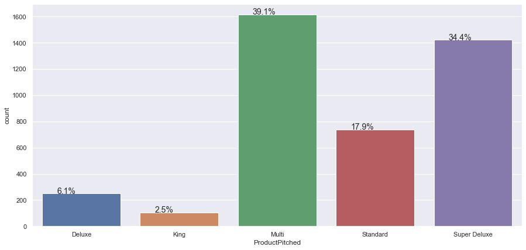

```python
perc_on_bar(data1['ProductPitched'])
```

- The MultiProduct and the SuperDeluxe are the most pitched products by a sales person

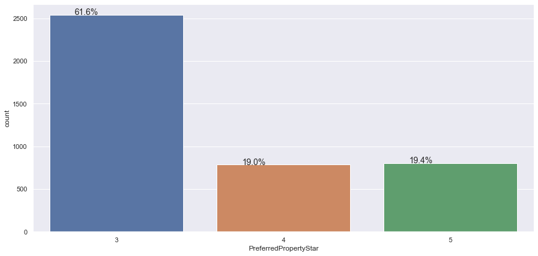

```python
perc_on_bar(data1['PreferredPropertyStar'])
```

- The 3 StarProperty is the prefered by the costumers

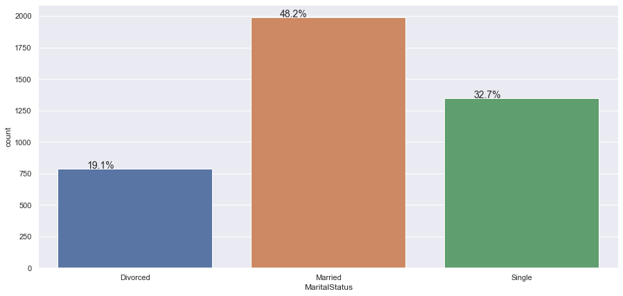

```python
perc_on_bar(data1['MaritalStatus'])
```

- The Married and the Single are the usual MaritalStatus in the costumers

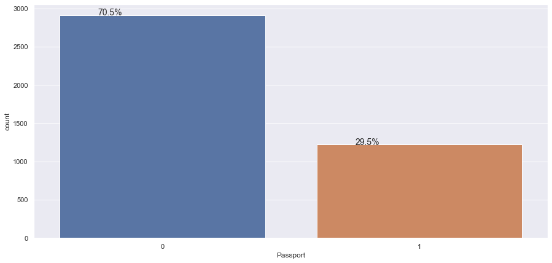

```python
perc_on_bar(data1['Passport'])
```

- Most of the costumers dont have Passport

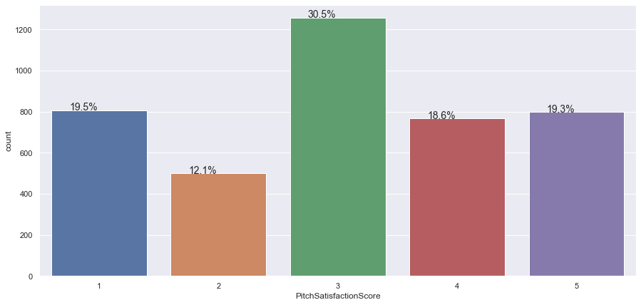

```python
perc_on_bar(data1['PitchSatisfactionScore'])
```

- In general, the costumers are satisfied with the pitches given by the sales person

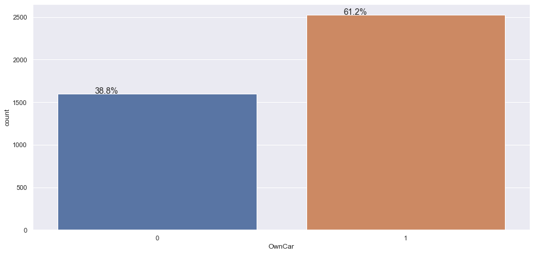

```python
perc_on_bar(data1['OwnCar'])
```

- The 61% of costumers have their own car

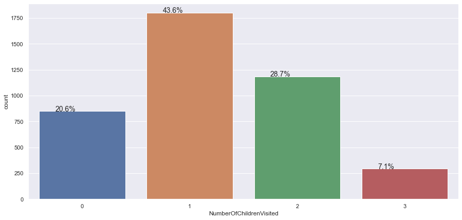

```python
perc_on_bar(data1['NumberOfChildrenVisited'])
```

- The costumers receive the pitch of the sales person with 1 or 2 children as the more usual number

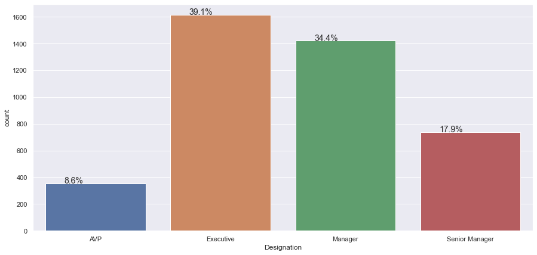

```python
perc_on_bar(data1['Designation'])
```

- Managers and Executives are the most usual positions of the costumers

### Bivariate analysis

```python
# Recalling the dataset
data1.info()
```

```
<class 'pandas.core.frame.DataFrame'>
Int64Index: 4128 entries, 0 to 4887
Data columns (total 19 columns):
 #   Column                   Non-Null Count  Dtype
---  ------                   --------------  -----
 0   ProdTaken                4128 non-null   int64
 1   Age                      4128 non-null   int64
 2   PreferredLoginDevice     4128 non-null   category
 3   CityTier                 4128 non-null   int64
 4   DurationOfPitch          4128 non-null   int64
 5   Occupation               4128 non-null   category
 6   Gender                   4128 non-null   category
 7   NumberOfPersonVisited    4128 non-null   int64
 8   NumberOfFollowups        4128 non-null   int64
 9   ProductPitched           4128 non-null   category
 10  PreferredPropertyStar    4128 non-null   int64
 11  MaritalStatus            4128 non-null   category
 12  NumberOfTrips            4128 non-null   int64
 13  Passport                 4128 non-null   int64
 14  PitchSatisfactionScore   4128 non-null   int64
 15  OwnCar                   4128 non-null   int64
 16  NumberOfChildrenVisited  4128 non-null   int64
 17  Designation              4128 non-null   category
 18  MonthlyIncome            4128 non-null   int64
dtypes: category(6), int64(13)
memory usage: 636.5 KB
```

```python
# we start checking through the crosstab function the possible dependencies of ProdTaken
columnas = data1.columns[1:18]
print(columnas)
for i in columnas:
    print(pd.crosstab(data1[i],data1['ProdTaken'],normalize='columns'))
```

```
Index(['Age', 'PreferredLoginDevice', 'CityTier', 'DurationOfPitch',
       'Occupation', 'Gender', 'NumberOfPersonVisited', 'NumberOfFollowups',
       'ProductPitched', 'PreferredPropertyStar', 'MaritalStatus',
       'NumberOfTrips', 'Passport', 'PitchSatisfactionScore', 'OwnCar',
       'NumberOfChildrenVisited', 'Designation'],
      dtype='object')
ProdTaken         0         1
Age
18         0.001801  0.010038
19         0.002101  0.026349
20         0.003903  0.028858
21         0.005404  0.026349
22         0.008106  0.018821
23         0.009907  0.016311
24         0.009006  0.020075
25         0.013209  0.023839
26         0.017412  0.041405
27         0.028520  0.037641
28         0.033323  0.030113
29         0.032423  0.070263
30         0.043230  0.055207
31         0.045632  0.045169
32         0.042930  0.042660
33         0.042029  0.047679
34         0.044131  0.050188
35         0.054938  0.038896
36         0.057340  0.030113
37         0.046533  0.027604
38         0.047133  0.017566
39         0.039628  0.016311
40         0.030922  0.026349
41         0.033924  0.030113
42         0.029421  0.025094
43         0.029421  0.011292
44         0.021615  0.021330
45         0.024617  0.017566
46         0.028820  0.010038
47         0.015611  0.013802
48         0.013209  0.013802
49         0.015011  0.008783
```

[output cut: 123 more lines]

```
OwnCar
0          0.38577  0.396487
1          0.61423  0.603513
ProdTaken                       0         1
NumberOfChildrenVisited
0                        0.206845  0.200753
1                        0.436506  0.434128
2                        0.286400  0.291092
3                        0.070249  0.074028
ProdTaken              0         1
Designation
AVP             0.097869  0.035132
Executive       0.339237  0.608532
Manager         0.377364  0.207026
Senior Manager  0.185530  0.149310
```

```python
# Converting the 'categorical' data in 'numeric' data to be able to make a pairplot later
from sklearn.preprocessing import LabelEncoder
le = LabelEncoder()
data2 = data1.copy()  #we make another copy of the data
data2['PreferredLoginDevice_le']=le.fit_transform(data2.PreferredLoginDevice)
data2['Occupation_le']=le.fit_transform(data2.Occupation)
data2['Gender_le']=le.fit_transform(data2.Gender)
data2['ProductPitched_le']=le.fit_transform(data2.ProductPitched)
data2['MaritalStatus_le']=le.fit_transform(data2.MaritalStatus)
data2['Designation_le']=le.fit_transform(data2.Designation)
# we drop the old colummns with categorical datatypes
data2.drop(['PreferredLoginDevice','Occupation','Gender','ProductPitched','MaritalStatus','Designation'], axis=1, inplace=True)
data2.info()
data2.nunique()
# Checking the new labeling in one of the columns
print(data2['Occupation_le'].value_counts())
print(data1['Occupation'].value_counts())
```

```
<class 'pandas.core.frame.DataFrame'>
Int64Index: 4128 entries, 0 to 4887
Data columns (total 19 columns):
 #   Column                   Non-Null Count  Dtype
---  ------                   --------------  -----
 0   ProdTaken                4128 non-null   int64
 1   Age                      4128 non-null   int64
 2   CityTier                 4128 non-null   int64
 3   DurationOfPitch          4128 non-null   int64
 4   NumberOfPersonVisited    4128 non-null   int64
 5   NumberOfFollowups        4128 non-null   int64
 6   PreferredPropertyStar    4128 non-null   int64
 7   NumberOfTrips            4128 non-null   int64
 8   Passport                 4128 non-null   int64
 9   PitchSatisfactionScore   4128 non-null   int64
 10  OwnCar                   4128 non-null   int64
 11  NumberOfChildrenVisited  4128 non-null   int64
 12  MonthlyIncome            4128 non-null   int64
 13  PreferredLoginDevice_le  4128 non-null   int32
 14  Occupation_le            4128 non-null   int32
 15  Gender_le                4128 non-null   int32
 16  ProductPitched_le        4128 non-null   int32
 17  MaritalStatus_le         4128 non-null   int32
 18  Designation_le           4128 non-null   int32
dtypes: int32(6), int64(13)
memory usage: 708.2 KB
1    1999
2    1746
0     383
Name: Occupation_le, dtype: int64
Salaried          1999
Small Business    1746
Large Business     383
Name: Occupation, dtype: int64
```

```
Index(['Age', 'CityTier', 'DurationOfPitch', 'NumberOfPersonVisited',
       'NumberOfFollowups', 'PreferredPropertyStar', 'NumberOfTrips',
       'Passport', 'PitchSatisfactionScore', 'OwnCar',
       'NumberOfChildrenVisited', 'MonthlyIncome', 'PreferredLoginDevice_le',
       'Occupation_le', 'Gender_le', 'ProductPitched_le', 'MaritalStatus_le',
       'Designation_le'],
      dtype='object')
```

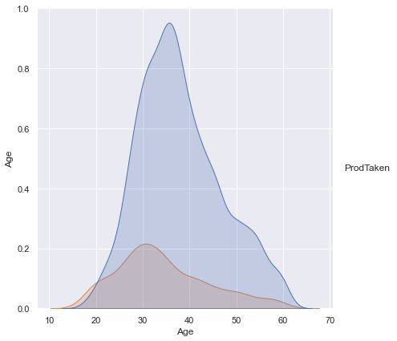

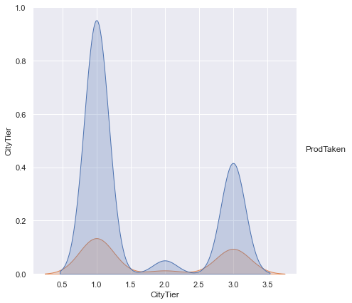

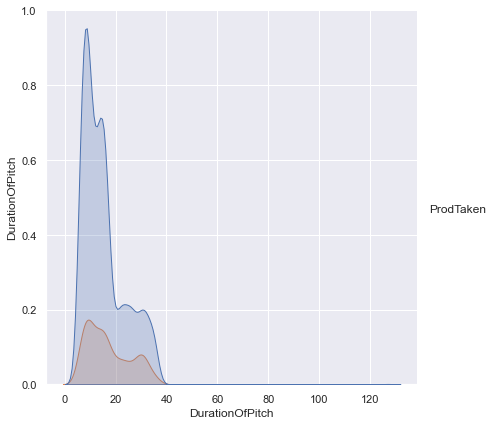

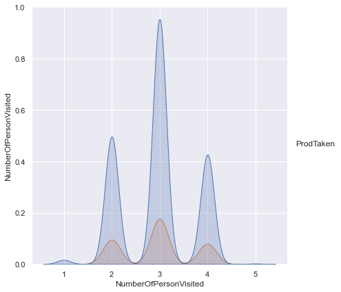

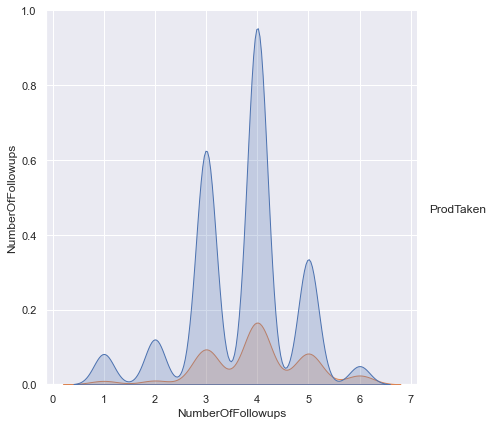

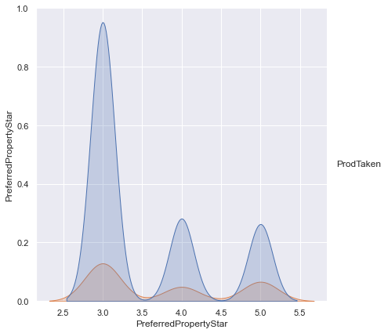

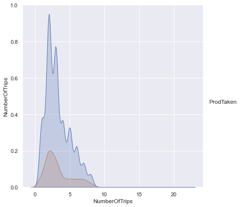

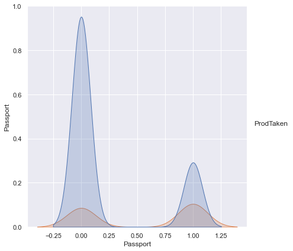

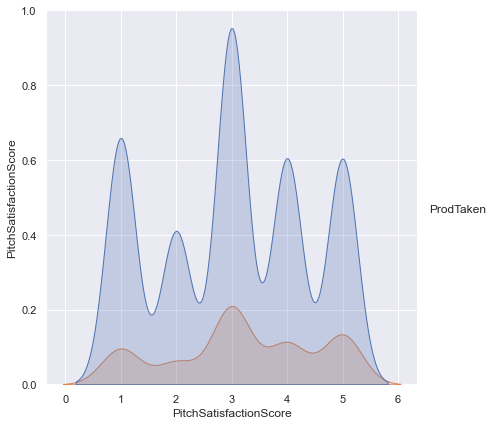

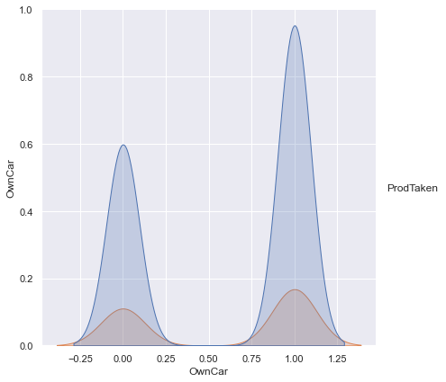

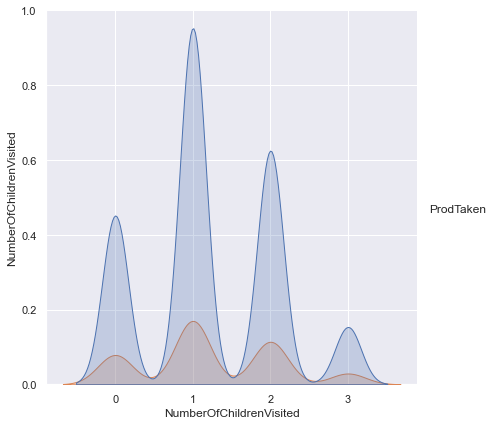

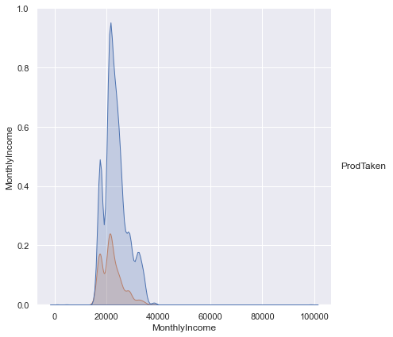

[6 more figures not shown]

```python
# we plot the distribution of each variable grouping by the ProdTaken
columnas = data2.columns[1:19]
print(columnas)
for i in columnas:
    plt.figure(figsize=(30,30))
    sns.pairplot(data2, x_vars=[i],y_vars=[i], hue = 'ProdTaken', size=6)
    plt.show()
```

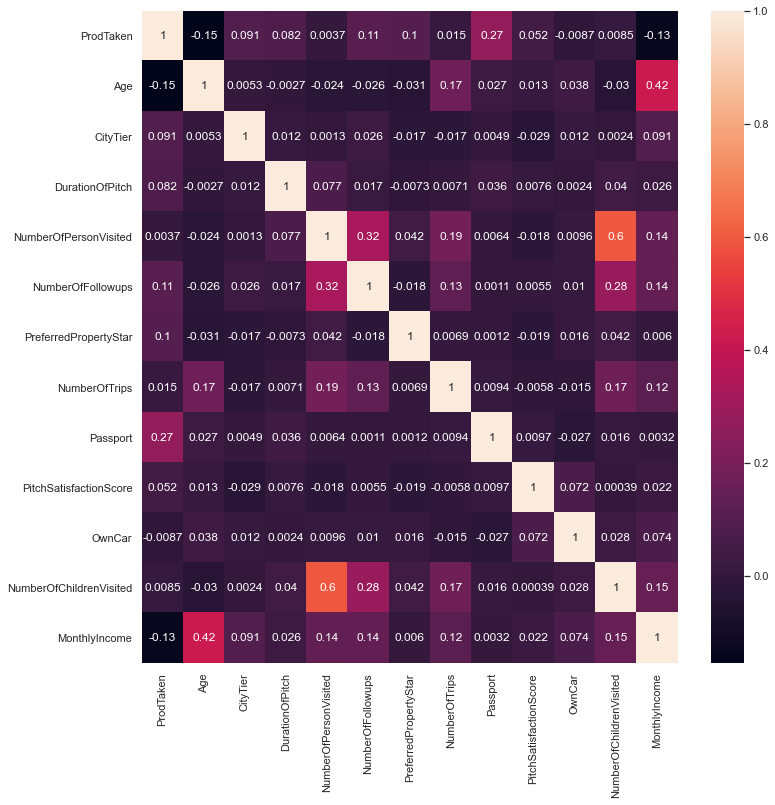

```python
# the correlation in data1 can finally disclose the dependencies of ProdTaken respect to the other variables
corr = data1.corr()
plt.figure(figsize=(12,12))
sns.heatmap(corr, annot = True)
plt.show()
```

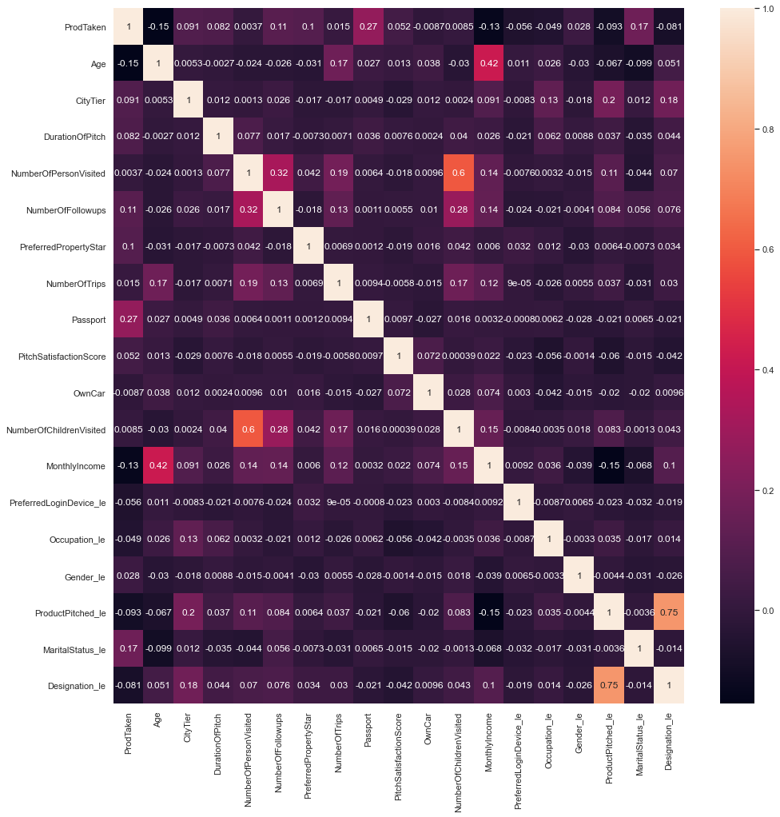

```python
# the correlation in data2 can finally disclose the dependencies of ProdTaken respect to all the other variables
corr = data2.corr()
plt.figure(figsize=(16,16))
sns.heatmap(corr, annot = True)
plt.show()
```

**Key meaningful observations based on the EDA**

- We can see the dependences between the variables and ProdTaken in the pairplots.
- We can confirm with the correlation matrix our visual insights obtained in the pairplots.
- Our analysis confirms that the next columns of data should be conserved in the final dataframe to be used to create the models: 'ProdTaken','Age', 'CityTier', 'DurationOfPitch','NumberOfFollowups', 'PreferredPropertyStar','Passport','MonthlyIncome','ProductPitched', 'MaritalStatus','Designation'.

## Data Pre-processing

### Data Pre-processing

- Prepare the data for analysis - Missing value Treatment, Outlier Detection(treat, if needed- why or why not ), Feature Engineering, Prepare data for modeling
- Split the Dataset

```python
#Dropping columns and leaving the columns before mentioned in the EDA in a new dataframe data3
data3 = data1[['ProdTaken','Age', 'CityTier', 'DurationOfPitch','NumberOfFollowups', 'PreferredPropertyStar',
       'Passport','MonthlyIncome','ProductPitched', 'MaritalStatus','Designation']].copy()
data3.head()
```

|  | ProdTaken | Age | CityTier | DurationOfPitch | NumberOfFollowups | PreferredPropertyStar | Passport | MonthlyIncome | ProductPitched | MaritalStatus | Designation |
| --- | --- | --- | --- | --- | --- | --- | --- | --- | --- | --- | --- |
| 0 | 1 | 41 | 3 | 6 | 3 | 3 | 1 | 20993 | Super Deluxe | Single | Manager |
| 1 | 0 | 49 | 1 | 14 | 4 | 4 | 0 | 20130 | Super Deluxe | Divorced | Manager |
| 2 | 1 | 37 | 1 | 8 | 4 | 3 | 1 | 17090 | Multi | Single | Executive |
| 3 | 0 | 33 | 1 | 9 | 3 | 3 | 1 | 17909 | Multi | Divorced | Executive |
| 5 | 0 | 32 | 1 | 8 | 3 | 3 | 0 | 18068 | Multi | Single | Executive |

```python
# Generating the dummies with the categorical variables
oneHotCols=['ProductPitched', 'MaritalStatus','Designation']
data3=pd.get_dummies(data3, columns=oneHotCols)
data3.head(10)
```

|  | ProdTaken | Age | CityTier | DurationOfPitch | NumberOfFollowups | PreferredPropertyStar | Passport | MonthlyIncome | ProductPitched_Deluxe | ProductPitched_King | ProductPitched_Multi | ProductPitched_Standard | ProductPitched_Super Deluxe | MaritalStatus_Divorced | MaritalStatus_Married | MaritalStatus_Single | Designation_AVP | Designation_Executive | Designation_Manager | Designation_Senior Manager |
| --- | --- | --- | --- | --- | --- | --- | --- | --- | --- | --- | --- | --- | --- | --- | --- | --- | --- | --- | --- | --- |
| 0 | 1 | 41 | 3 | 6 | 3 | 3 | 1 | 20993 | 0 | 0 | 0 | 0 | 1 | 0 | 0 | 1 | 0 | 0 | 1 | 0 |
| 1 | 0 | 49 | 1 | 14 | 4 | 4 | 0 | 20130 | 0 | 0 | 0 | 0 | 1 | 1 | 0 | 0 | 0 | 0 | 1 | 0 |
| 2 | 1 | 37 | 1 | 8 | 4 | 3 | 1 | 17090 | 0 | 0 | 1 | 0 | 0 | 0 | 0 | 1 | 0 | 1 | 0 | 0 |
| 3 | 0 | 33 | 1 | 9 | 3 | 3 | 1 | 17909 | 0 | 0 | 1 | 0 | 0 | 1 | 0 | 0 | 0 | 1 | 0 | 0 |
| 5 | 0 | 32 | 1 | 8 | 3 | 3 | 0 | 18068 | 0 | 0 | 1 | 0 | 0 | 0 | 0 | 1 | 0 | 1 | 0 | 0 |
| 6 | 0 | 59 | 1 | 9 | 2 | 5 | 1 | 17670 | 0 | 0 | 1 | 0 | 0 | 1 | 0 | 0 | 0 | 1 | 0 | 0 |
| 7 | 0 | 30 | 1 | 30 | 3 | 3 | 0 | 17693 | 0 | 0 | 1 | 0 | 0 | 0 | 1 | 0 | 0 | 1 | 0 | 0 |
| 8 | 0 | 38 | 1 | 29 | 4 | 3 | 0 | 24526 | 0 | 0 | 0 | 1 | 0 | 0 | 0 | 1 | 0 | 0 | 0 | 1 |
| 9 | 0 | 36 | 1 | 33 | 3 | 3 | 0 | 20237 | 0 | 0 | 0 | 0 | 1 | 1 | 0 | 0 | 0 | 0 | 1 | 0 |
| 10 | 0 | 35 | 1 | 22 | 2 | 4 | 0 | 17426 | 0 | 0 | 1 | 0 | 0 | 1 | 0 | 0 | 0 | 1 | 0 | 0 |

```python
#Resume of data ready to model
data3.info()
```

```
<class 'pandas.core.frame.DataFrame'>
Int64Index: 4128 entries, 0 to 4887
Data columns (total 20 columns):
 #   Column                       Non-Null Count  Dtype
---  ------                       --------------  -----
 0   ProdTaken                    4128 non-null   int64
 1   Age                          4128 non-null   int64
 2   CityTier                     4128 non-null   int64
 3   DurationOfPitch              4128 non-null   int64
 4   NumberOfFollowups            4128 non-null   int64
 5   PreferredPropertyStar        4128 non-null   int64
 6   Passport                     4128 non-null   int64
 7   MonthlyIncome                4128 non-null   int64
 8   ProductPitched_Deluxe        4128 non-null   uint8
 9   ProductPitched_King          4128 non-null   uint8
 10  ProductPitched_Multi         4128 non-null   uint8
 11  ProductPitched_Standard      4128 non-null   uint8
 12  ProductPitched_Super Deluxe  4128 non-null   uint8
 13  MaritalStatus_Divorced       4128 non-null   uint8
 14  MaritalStatus_Married        4128 non-null   uint8
 15  MaritalStatus_Single         4128 non-null   uint8
 16  Designation_AVP              4128 non-null   uint8
 17  Designation_Executive        4128 non-null   uint8
 18  Designation_Manager          4128 non-null   uint8
 19  Designation_Senior Manager   4128 non-null   uint8
dtypes: int64(8), uint8(12)
memory usage: 498.6 KB
```

```python
# We import the libraries we need
from sklearn import metrics
from sklearn.model_selection import GridSearchCV, train_test_split
from sklearn.tree import DecisionTreeClassifier
from sklearn.linear_model import LogisticRegression
from sklearn.ensemble import BaggingClassifier, RandomForestClassifier
from sklearn.ensemble import AdaBoostClassifier, GradientBoostingClassifier, StackingClassifier
from xgboost import XGBClassifier
```

```python
# Separating features and the target column ProdTaken
X = data3.drop('ProdTaken', axis=1)
y = data3['ProdTaken']
```

```python
# Splitting the data into train and test sets in 70:30 ratio
X_train, X_test, y_train, y_test = train_test_split(X, y, test_size=0.30, random_state=1, shuffle=True)
```

```python
X_train.shape, X_test.shape
```

```
((2889, 19), (1239, 19))
```

- We have 2889 observations in the train set and 1239 observations in the test set.